# Assignment 2

Hunter Holt

2026-05-26

```r
reviews <- read.csv("SoftwareReviews.csv") |>
  mutate(
         id = row_number(),
         y = rating,
         text = as.character(text)
  )
glimpse(reviews)
```

```
## Rows: 10,000
## Columns: 11
## $ rating            <int> 1, 5, 5, 4, 4, 4, 5, 5, 1, 4, 2, 5, 5, 2, 4, 5, 1, 5…
## $ title             <chr> "malware", "Lots of Fun", "Light Up The Dark", "Fun …
## $ text              <chr> "mcaffee IS malware", "I love playing tapped out bec…
## $ images            <chr> "[]", "[]", "[]", "[]", "[]", "[]", "[]", "[]", "[]"…
## $ asin              <chr> "B07BFS3G7P", "B00CTQ6SIG", "B0066WJLU6", "B00KCYMAW…
## $ parent_asin       <chr> "B0BQSK9QCF", "B00CTQ6SIG", "B0066WJLU6", "B00KCYMAW…
## $ user_id           <chr> "AGCI7FAH4GL5FI65HYLKWTMFZ2CQ", "AHSPLDNW5OOUK2PLH7G…
## $ helpful_vote      <int> 0, 0, 0, 0, 0, 0, 0, 0, 0, 0, 0, 0, 1, 0, 0, 11, 1, …
## $ verified_purchase <lgl> FALSE, TRUE, TRUE, TRUE, TRUE, TRUE, TRUE, FALSE, FA…
## $ id                <int> 1, 2, 3, 4, 5, 6, 7, 8, 9, 10, 11, 12, 13, 14, 15, 1…
## $ y                 <int> 1, 5, 5, 4, 4, 4, 5, 5, 1, 4, 2, 5, 5, 2, 4, 5, 1, 5…
```

To begin, we use `set.seed(123)` for reproducible splitting and downstream randomness. This is standard within this report. We note that the dataset contains nine variables: `rating` (0 - 5), `title`, `text`, `images` (URL), `asin`, `parent_asin` (Amazon Standard Identification Number, an alphanumeric ten-digit code for identifying products), `user_id`, `helpful_vote` (a count of how many other users felt the review was helpful), and `verified_purchase` (a boolean used to signify whether the review followed a purchase, or was otherwise unprompted). Of these nine variables, the one we focus on is the `text` field, as it is already separated from metadata, which allows for our sparse matrix to be developed without too much additional parsing. The `title` field may prove useful moving forward, but to begin, we focus on the review body since it is methodologically cleaner to work with.

```r
# Clean, tokenise
reviews_tokens <- reviews |>
  unnest_tokens(word, text) |>
  anti_join(get_stopwords()) |>
  filter(str_detect(word, "^[a-z']+$"))
# Create dfm
dfm <- reviews_tokens |>
  count(id, word) |>
  cast_sparse(id, word, n)

# Align response vector to dfm rows
y <- reviews$y[as.numeric(rownames(dfm))]
```

We essentially build a sparse document frequency matrix (DFM) to feed `glmnet`, which requires a numeric matrix and a numeric response.

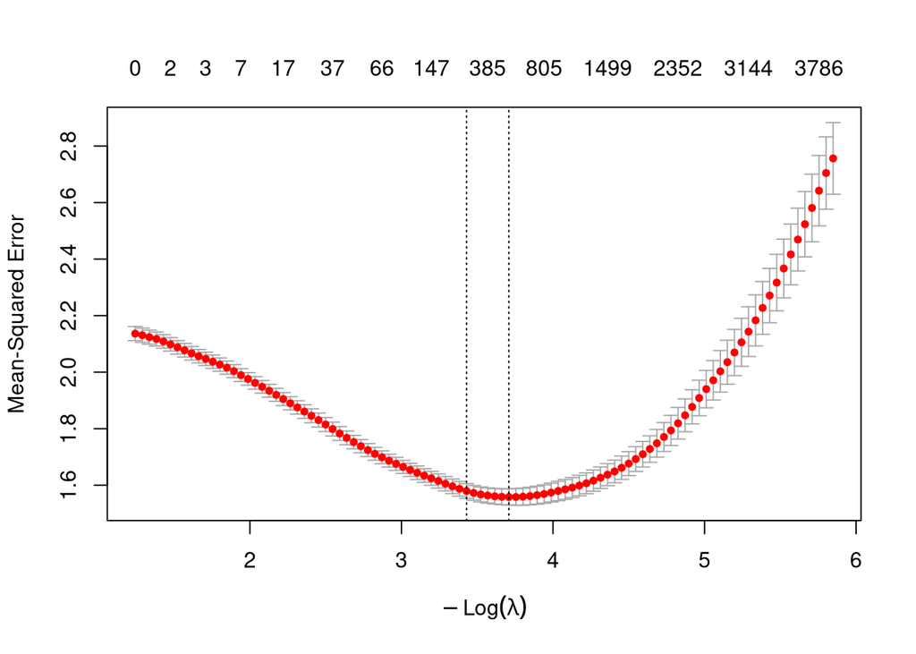

```r
trainIndex <- createDataPartition(y, p = 0.8, list = FALSE)
x_train <- dfm[trainIndex, ]
x_test <- dfm[-trainIndex, ]
y_train <- y[trainIndex]
y_test <- y[-trainIndex]
cv_fit <- cv.glmnet(x = x_train, y = y_train, alpha = 1, family = "gaussian", nfolds = 5)
plot(cv_fit)
```

```r
best_lambda <- cv_fit$lambda.min
lambda_1se <- cv_fit$lambda.1se
best_lambda; lambda_1se
```

```
## [1] 0.02451126
```

```
## [1] 0.03240244
```

Here, we use Lasso regression, with an alpha = 1, and choose lambda.min (which produces the best cross-validation mean standard error) and lambda.1se (a more regularised, simpler model). `glmnet` will compute the regularisation path and cross-validation internally. Essentially, the function `cv_fit <- cv.glmnet(...)` computes the regression model for a sequence of lambda values, evaluates each one using K-folds cross-validation, and returns `lambda.min` (the lambda that produces the lowest cross-validated error), as well as `lambda.1se` (the lambda that is within one standard error of the minimum).

The reason we have the both of these lambda values:

- `lambda_min` provides the best predictive performance, whereas
- `lambda_1se` provides a more interpretable, regularised model.

```r
pred_min <- predict(cv_fit, newx = x_test, s = best_lambda)
pred_1se <- predict(cv_fit, newx = x_test, s = lambda_1se)

rmse <- function(obs, pred) sqrt(mean((obs - pred)^2))
mae <- function(obs, pred) mean(abs(obs - pred))

tibble(
       model = c("lambda.min", "lambda.1se"),
       RMSE = c(rmse(y_test, pred_min), rmse(y_test, pred_1se)),
       MAE = c(mae(y_test, pred_min), mae(y_test, pred_1se))
)
```

```
## # A tibble: 2 × 3
##   model       RMSE   MAE
##   <chr>      <dbl> <dbl>
## 1 lambda.min  1.23  1.00
## 2 lambda.1se  1.24  1.02
```

The `plot(cv_fit)` above shows cross-validation MSE against `log(lambda)`; below we include a scatter plot of predicted against actual ratings to inspect bias and variance.

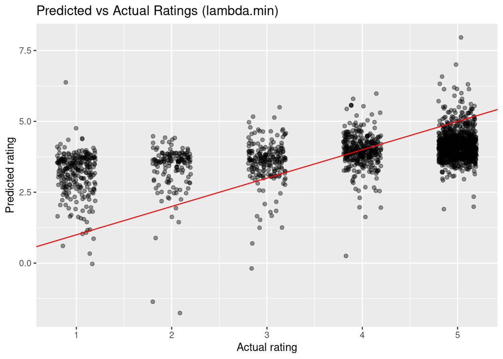

```r
pred_df <- tibble(actual = y_test, pred = as.numeric(pred_min))
ggplot(pred_df, aes(x = actual, y = pred)) +
  geom_jitter(width = 0.2, height = 0.2, alpha = 0.4) +
  geom_abline(slope = 1, intercept = 0, color = "red") +
  labs(title = "Predicted vs Actual Ratings (lambda.min)", x = "Actual rating", y = "Predicted rating")
```